# itsar-vignette

William M. Old, Kristofor Webb

6/11/2020

## Using the itsar package to identify protein targets of staurosporine from a protein lysate experiment

This vignette demonstrates how to use the **itsar** package to analyze thermal profiling proteomic data collected using the isothermal shift assay (iTSA) method as published in Ball, KA et al. 2020. This method provides improved experimental design and statistical power for identifying the binding targets of small molecules in complex proteomes, in either lysates or cells.

You can see more documentation of the itsar package once installed by typing at the command prompt `?itsar`. Once there, click on the “Index” hyperlink at the bottom of page to see a list of functions, each with documentation.

iTSA Paper: Ball KA, Webb KJ, Coleman SJ, Cozzolino KA, Jacobsen J, Jones KR, Stowell MHB, Old WM (2020). An isothermal shift assay for proteome scale drug-target identification. Communications Biology 3, 1–10. DOI: 10.1038/s42003-020-0795-6

## Load required packages for this vignette

Load R packages, including the itsar package (make sure it is installed from CU Boulder Old lab GitHub)

```r
library(itsar)
library(tidyverse)
require(magrittr)
require(dplyr)
require(limma)
require(sva)

options(stringsAsFactors = FALSE)
```

Ensure that sample names and data column names are correct by reading in the header for the proteinGroups.txt file. In this example, we are analyzing data from the iTSA paper that performed an iTSA experiment at 52C using the broad spectrum kinase inhibitor, staurosporine. MaxQuant was used to quantify the Drug vs. Control TMT10 experiment in which drug and vehicle conditions alternated channels across the 10-plex (see paper for more details). The MaxQuant proteinGroups.txt file contains the protein-level TMT channel intensities that have been corrected for channel-specific isotope impurities, with protein annotation information as well. We only focus on the 52C experiment here.

```r
#Read proteinGroups file
proteinGroupFile <- system.file("extdata",
                                       "proteinGroups_itsa_staurosporine_3temp_20190402KB.txt.gz",
                                       package = "itsar")
# read the first line of file to retrieve the column names, for properly setting up the sample names
# gzfile() is used because we are reading a gzipped tab delimited file
#
pgfilecolnames <- as.character(
   read.table(
      file = gzfile(proteinGroupFile),
      header = F,
      nrows = 1,
      sep = "\t",
      na.strings = c("NA","NaN","Infinite"),
      fill = T,
      stringsAsFactors = F,
      quote = "\"")[1,])

### Filter data columns & define TMT data columns
# identifies column numbers that contain Label corrected intensity data (TMT lot-specific correction)
tmtdata_colnames <- grep("Reporter intensity corrected \\d+ 52C", pgfilecolnames, value = T)
```

Use the `itsar::read_maxquant_proteingroupfile()` function to read in the TMT protein data into a data frame and convert to tibble (see dplyr package for more information on tibbles and tidyverse. This function returns a list containing a data frame of the protein TMT data and a character vector of column names.

```r
plist <- itsar::read_maxquant_proteingroupfile(
  proteinGroups.filename = proteinGroupFile,
  datacolnames = tmtdata_colnames,
  uniprot.id.column = "Majority protein IDs",
  uniprot.acc.column = "Fasta headers",
  null.zeros = T,
  log2.transform = F,
  is.gzip.file = T)

prot.table <- plist$prot.table
tmtdata_colnames <- plist$prot.colnms

tmtdata_colnames
```

```
#>  [1] "Reporter.intensity.corrected.1.52C"  "Reporter.intensity.corrected.2.52C"
#>  [3] "Reporter.intensity.corrected.3.52C"  "Reporter.intensity.corrected.4.52C"
#>  [5] "Reporter.intensity.corrected.5.52C"  "Reporter.intensity.corrected.6.52C"
#>  [7] "Reporter.intensity.corrected.7.52C"  "Reporter.intensity.corrected.8.52C"
#>  [9] "Reporter.intensity.corrected.9.52C"  "Reporter.intensity.corrected.10.52C"
```

```r
prot.table <- as_tibble(prot.table)
```

Remove poorly quantified proteins with less than 2 unique peptides, using the dplyr function `dplyr::filter`

```r
# Remove poorly quantified proteins with less than 2 unique peptides
prot.table <- dplyr::filter(prot.table, Reverse != "+",
                            Potential.contaminant != "+",
                            Only.identified.by.site != "+",
                             Reporter.intensity.count.3.52C > 2,
                            Unique.peptides > 1)
```

```r
# Are there any duplicated gene names?

prot.table$Gene.names %>% duplicated() %>% any()
```

```
#> [1] TRUE
```

```r
prot.table %>% dplyr::group_by(Gene.names) %>%
  dplyr::summarize(frequency = n()) %>%
  dplyr::arrange(desc(frequency)) %>%
  dplyr::filter(frequency > 1)
```

```
#> # A tibble: 45 x 2
#>   Gene.names frequency
#>   <chr>          <int>
#> 1 ""                 7
#> 2 "MAP4"             3
#> 3 "TMPO"             3
#> 4 "ACLY"             2
#> # ... with 41 more rows
```

```r
#prot.table <- DEP::make_unique(prot.table, "Gene.names", "Protein.IDs", delim = ";")

# prot.table %>% dplyr::group_by(name) %>%
#   dplyr::summarize(frequency = n()) %>%
#   dplyr::arrange(desc(frequency)) %>%
#   dplyr::filter(frequency > 1)
```

Check the densities of TMT data, will be lognormally distributed if columns haven’t been log2 transformed

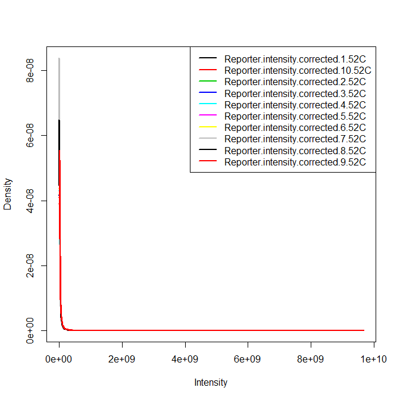

```r
limma::plotDensities(prot.table[,tmtdata_colnames], legend = "topright")
```

Log2 transform and quantile normalize

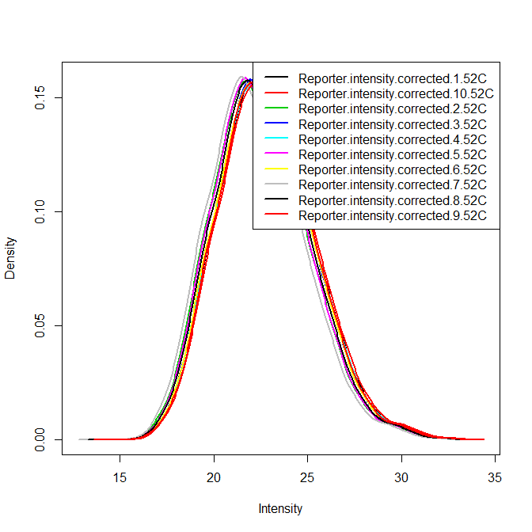

```r
prot.table[,tmtdata_colnames] <- log2(prot.table[,tmtdata_colnames] )

limma::plotDensities(prot.table[,tmtdata_colnames], legend = "topright")
```

```r
prot.table[,tmtdata_colnames] <- limma::normalizeBetweenArrays(as.matrix(prot.table[,tmtdata_colnames]),
                                                        method="quantile" )
```

Set up the targets matrix, which describes the experimental design. We are going to compare two models, one in which we correct for unexplained batch effects, and one in which we don’t. First set up two different model matrices

```r
targets <- data.frame(samples = tmtdata_colnames,
                      treatment = factor(rep(c("Vehicle","Drug"), 5), levels = c("Vehicle","Drug")))
targets
```

```
#>                                samples treatment
#> 1   Reporter.intensity.corrected.1.52C   Vehicle
#> 2   Reporter.intensity.corrected.2.52C      Drug
#> 3   Reporter.intensity.corrected.3.52C   Vehicle
#> 4   Reporter.intensity.corrected.4.52C      Drug
#> 5   Reporter.intensity.corrected.5.52C   Vehicle
#> 6   Reporter.intensity.corrected.6.52C      Drug
#> 7   Reporter.intensity.corrected.7.52C   Vehicle
#> 8   Reporter.intensity.corrected.8.52C      Drug
#> 9   Reporter.intensity.corrected.9.52C   Vehicle
#> 10 Reporter.intensity.corrected.10.52C      Drug
```

```r
origdesign <- model.matrix(~0+treatment, data = targets)
colnames(origdesign) <- c("Vehicle","Drug")  #V=Vehicle; D=Drug

origdesign
```

```
#>    Vehicle Drug
#> 1        1    0
#> 2        0    1
#> 3        1    0
#> 4        0    1
#> 5        1    0
#> 6        0    1
#> 7        1    0
#> 8        0    1
#> 9        1    0
#> 10       0    1
#> attr(,"assign")
#> [1] 1 1
#> attr(,"contrasts")
#> attr(,"contrasts")$treatment
#> [1] "contr.treatment"
```

```r
design <- model.matrix(~treatment, data = targets)
colnames(design) <- c("intercept","Drug")
```

## Statistical testing

Run model without the batch effect correction (empirical Bayes linear modeling)

```r
### Use limma for empirical bayes


fit <- limma::lmFit(prot.table[,tmtdata_colnames], origdesign)

fit <- limma::eBayes(fit) ##Apply empirical Bayes smoothing to the standard errors.
contrast <- limma::makeContrasts("Drug-Vehicle", levels=origdesign)

fit2 <- limma::contrasts.fit(fit, contrast)
fit2$Amean <- log2(prot.table$Intensity.52C)

fit2 <- limma::eBayes(fit2, trend = TRUE)
```

Use the get_toptable() function `itsar::get_toptable()` (from itsar package)

```r
pstats <- itsar::get_toptable(fit2,
                              coef = 1,
                              glist = prot.table[,c("id", "Gene.names", "uniprot.id")],
                              suffix = ".uncor" )

pstats <- pstats %>% arrange(P.Value.uncor)

sum(pstats$P.Value.uncor <= 0.05)
```

```
#> [1] 652
```

```r
sum(pstats$P.Value.uncor <= 0.01)
```

```
#> [1] 282
```

```r
sum(pstats$P.Value.uncor<= 0.001)
```

```
#> [1] 144
```

```r
pstats
```

```
#> # A tibble: 5,863 x 13
#>      id Gene.names.uncor uniprot.id.uncor logFC.uncor CI.L.uncor CI.R.uncor
#>   <int> <chr>            <chr>                  <dbl>      <dbl>      <dbl>
#> 1  2811 CDK5             Q00535                  1.56      1.51        1.61
#> 2  1928 MAP2K2           P36507                  1.56      1.50        1.62
#> 3  1687 ADRBK1           P25098                  1.39      1.33        1.45
#> 4  5937 SRPK1            Q96SB4                  1.04      0.994       1.08
#> # ... with 5,859 more rows, and 7 more variables: AveExpr.uncor <dbl>,
#> #   t.uncor <dbl>, P.Value.uncor <dbl>, adj.P.Val.uncor <dbl>, B.uncor <dbl>,
#> #   s2.post.uncor <dbl>, sigma.uncor <dbl>
```

Run model that incorporates latent variables that correct batch effects using the R package sva. sva creates surrogate variables that model batch effects in the data, which are then added to the specified variables used in the empirical Bayes linear modeling with limma.

```r
mod0 <- model.matrix(~1, data = targets)
colnames(mod0) <- "intercept"
dmat <- as.matrix(prot.table[,tmtdata_colnames])

numsv <- sva::num.sv(dmat, design, method = "be", B = 100)


svobj <- sva::sva(dmat,design,mod0,n.sv = 3)
```

```
#> Number of significant surrogate variables is:  3
#> Iteration (out of 5 ):1  2  3  4  5
```

```r
modSv = cbind(design,svobj$sv)
mod0Sv = cbind(mod0,svobj$sv)
pValuesSv = sva::f.pvalue(dmat,modSv,mod0Sv)
qValuesSv = p.adjust(pValuesSv,method="BH")
sum(qValuesSv < 0.1, na.rm = T)
```

```
#> [1] 552
```

```r
svafit <- lmFit(dmat , modSv)
contrast.matrix <- cbind("intercept" = c(1,0, rep(0,svobj$n.sv) ), "Drug"= c(0,1,rep(0,svobj$n.sv)))


fitContrasts = limma::contrasts.fit(svafit,contrast.matrix)

svafit$Amean <- log2(prot.table$Intensity.52C)

fit2_sva <- eBayes(fitContrasts, trend = TRUE)
```

Use the itsar function get_toptable() to retrieve all tested proteins, and sort by p-value. The p-values are corrected using the BH method.

```r
pstats_sva <- itsar::get_toptable(fit2_sva, coef = "Drug",
                                  glist = prot.table[,c("id", "Gene.names", "uniprot.id")],
                                  suffix = ".sva" )

pstats_sva <- pstats_sva %>% arrange(P.Value.sva)

sum(pstats_sva$adj.P.Val.sva <= 0.05)
```

```
#> [1] 517
```

```r
sum(pstats_sva$adj.P.Val.sva <= 0.01)
```

```
#> [1] 234
```

```r
sum(pstats_sva$adj.P.Val.sva<= 0.001)
```

```
#> [1] 139
```

```r
pstats_sva
```

```
#> # A tibble: 5,863 x 13
#>      id Gene.names.sva uniprot.id.sva logFC.sva CI.L.sva CI.R.sva AveExpr.sva
#>   <int> <chr>          <chr>              <dbl>    <dbl>    <dbl>       <dbl>
#> 1  1928 MAP2K2         P36507              1.55     1.51     1.58        24.8
#> 2  2007 CSK            P41240              1.21     1.17     1.24        24.8
#> 3  2811 CDK5           Q00535              1.55     1.51     1.60        23.1
#> 4  1687 ADRBK1         P25098              1.40     1.36     1.44        23.6
#> # ... with 5,859 more rows, and 6 more variables: t.sva <dbl>,
#> #   P.Value.sva <dbl>, adj.P.Val.sva <dbl>, B.sva <dbl>, s2.post.sva <dbl>,
#> #   sigma.sva <dbl>
```

## Plotting

Make volcano plots to show the relationship between the effect size for drug-induced thermal-stabilization (log2(Staurosporine/DMSO)) and -log10(p-value) for differential expression Uses the itsar function `itsar::ggvolcano()`

```r
pstats$logp <- -log10(pstats$P.Value.uncor)
pstats_sva$logp <- -log10(pstats_sva$P.Value.sva)
range(pstats$logp)
```

```
#> [1]  0.00000 15.18945
```

```r
range(pstats$logFC.uncor)
```

```
#> [1] -0.6592883  1.7805869
```

```r
range(pstats_sva$logp)
```

```
#> [1]  0.00000 14.30991
```

```r
range(pstats_sva$logFC.sva)
```

```
#> [1] -0.6493016  1.8151109
```

```r
volcanoplots_uncor <- itsar::ggvolcano(pstats, xvar = logFC.uncor,
                   yvar = logp,
                   labelvar = Gene.names.uncor,
                   adjpvalvar = adj.P.Val.uncor,
                   fdr.range.cut = c(0,0.01,0.1,1),
                   high.sig.threshold = 0.001,
                   annotgenes = T, xlimits = c(-2, 2), ylimits = c(0, 16))


volcanoplots_sva <- itsar::ggvolcano(pstats_sva, xvar = logFC.sva,
                   yvar = logp,
                   labelvar = Gene.names.sva,
                   adjpvalvar = adj.P.Val.sva,
                   fdr.range.cut = c(0,0.01,0.1,1),
                   high.sig.threshold = 0.001,
                   annotgenes = T, xlimits = c(-2, 2), ylimits = c(0, 16))
```

Volcano plot for uncorrected analysis

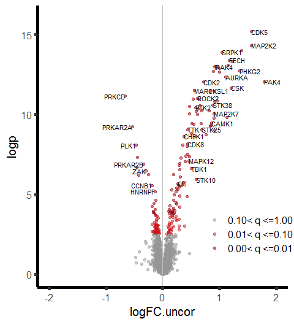

```r
volcanoplots_uncor$ggplot_volcano
```

Volcano plot for SVA batch corrected analyses:

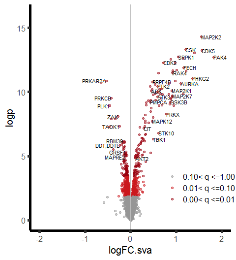

```r
volcanoplots_sva$ggplot_volcano
```

Interactive plotly volcano plots

```r
volcanoplots_uncor$plotly_volcano
```

[interactive chart not shown]

Volcano plot for SVA batch corrected analyses:

```r
volcanoplots_sva$plotly_volcano
```

[interactive chart not shown]